# Regression Analysis

Innocenter A.

07 July 2017

## Objectives

> 1. What is Regression Analysis?
> 2. What are the Types of Regression Analysis?
> 3. What are the assumptions for using a Linear Regression Model?
> 4. How to perform Diagnostic Testing of linear regression models?

## Introduction to Regression Analysis for Predictive Modelling

**Regression analysis** is a **predictive modelling** technique used to estimate and/or determine the **relationship** between **response** (dependent) variable(s) and **explanatory** (independent) varible(s).

> What are some of the types of regression techniques?

[Types Of Regression Techniques](https://www.analyticsvidhya.com/blog/2015/08/comprehensive-guide-regression/)

These regression techniques are mostly driven by three metrics

> 1. Number of independent variables,
> 2. Type of dependent variables and
> 3. Shape of regression line

For more information on the [metrics](https://www.analyticsvidhya.com/blog/2016/02/7-important-model-evaluation-error-metrics/)

## Importance of Regression analysis

> Regression analysis determines significant relationship between the variables (identifies most significant variables in case of multiple explanatory variables), and it can be used as a predictive tool.

# Linear Regression Modelling

A linear model

## Checking assumptions for using linear regression model using data

This is a simple example illustrating linear regression using *cars* data. The data set has observations recorded on the speed of cars and the distances taken to stop the cars.

## Goal

> 1. To build a regression model that can be used to predict distance by establishing a statistically significant linear relationship with speed.
> 2. Investigate various assumptions made before choosing a linear regression model.

Before choosing a regression technique, perform explorative statistics to better understand the data. This will help you to choose the best regression technique.

```r
head(cars) #prints 5 rows of the data
```

```
##   speed dist
## 1     4    2
## 2     4   10
## 3     7    4
## 4     7   22
## 5     8   16
## 6     9   10
```

```r
dim(cars) # prints number of rows and columns of the data
```

```
## [1] 50  2
```

```r
summary(cars) #descriptive statistics of the data
```

```
##      speed           dist
##  Min.   : 4.0   Min.   :  2.00
##  1st Qu.:12.0   1st Qu.: 26.00
##  Median :15.0   Median : 36.00
##  Mean   :15.4   Mean   : 42.98
##  3rd Qu.:19.0   3rd Qu.: 56.00
##  Max.   :25.0   Max.   :120.00
```

## Assumptions

> 1. The regression model is **linear** in parameters (Y and X have a linear relationship). A **scatter plot** can be used to visualize the linear relationship between the response and explanatory variable.

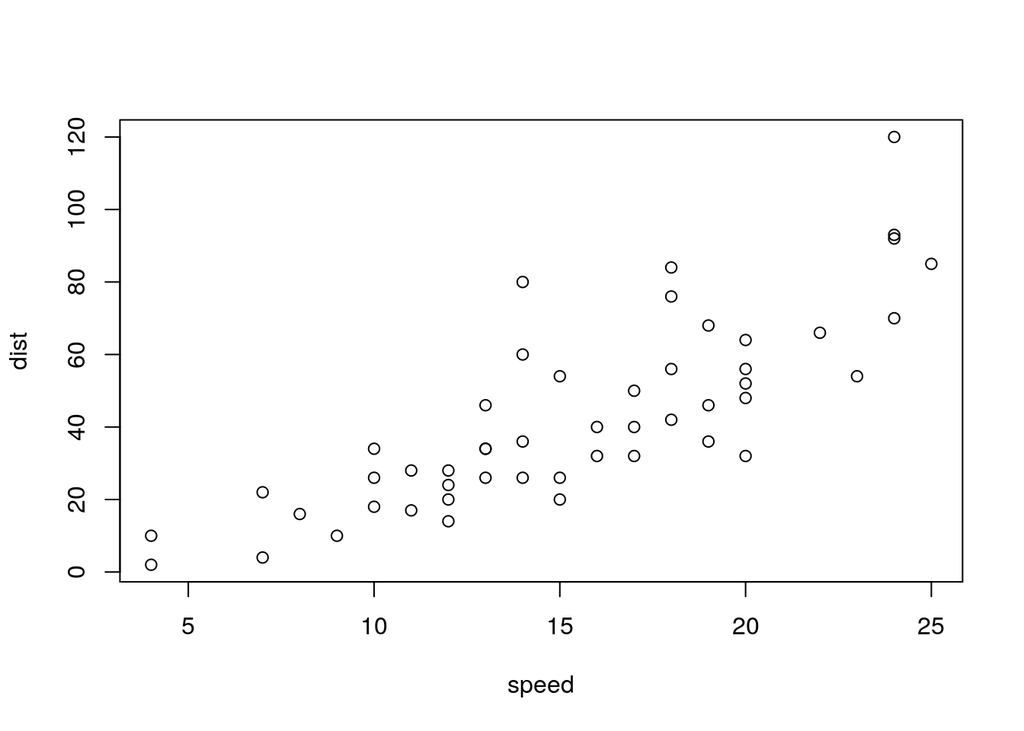

A plot showing the linear relationship using ggplot

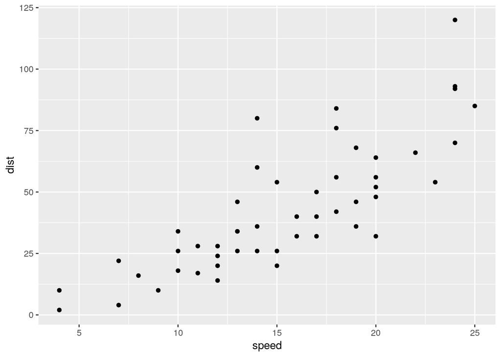

```r
ggplot(cars, aes(speed, dist))+geom_point() #scatter plot
```

If the explanatory variables are >1 then a smooth scatter plot for each one of them is drawn. This might not be viable for some datasets

> 2. **Outliers** can affect the prediction as they can easily the direction of the line of best fit. **Boxplots**, histograms and Tukey’s method can be used to detect outliers

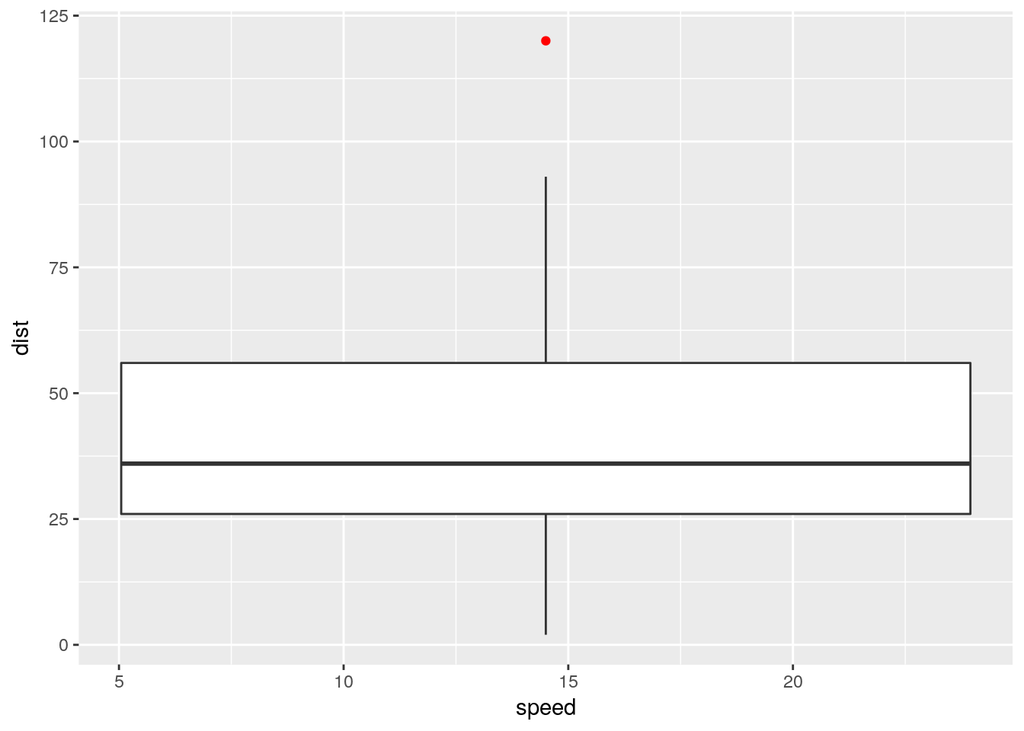

```r
ggplot(cars)+geom_boxplot(mapping=aes(speed, dist),stat = 'boxplot', outlier.color='red') #boxlot
```

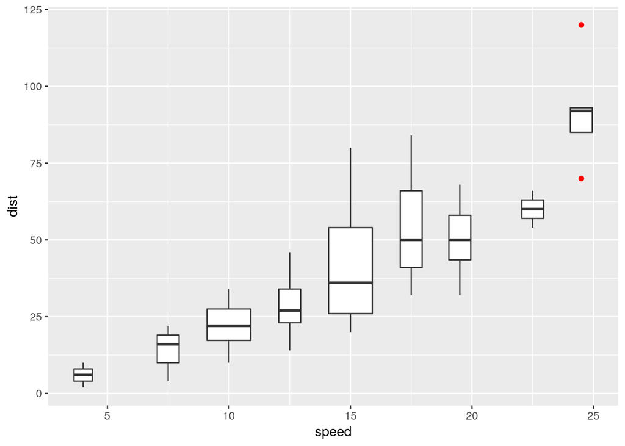

```r
ggplot(cars,aes(speed, dist))+geom_boxplot(aes(group = cut_width(speed, 2.5)), outlier.color='red')
```

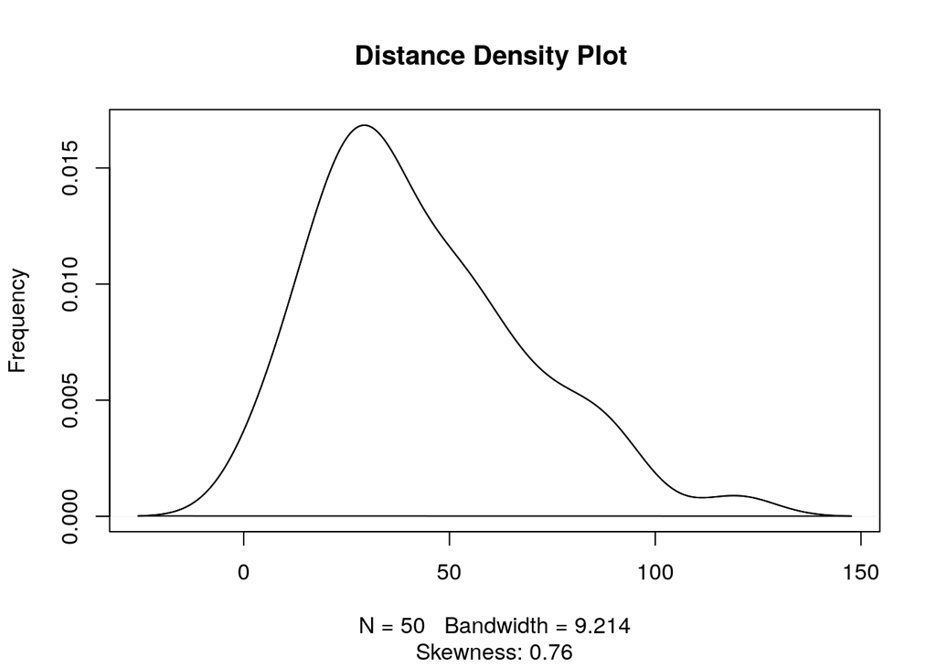

```r
plot(density(cars$dist), main="Distance Density Plot ", ylab="Frequency", sub=paste("Skewness:", round(e1071::skewness(cars$dist), 2)))  # density plot for 'dist'
polygon(density(cars$dist)) #plot density polygon
```

> 4. Correlation determines the level of linear dependence between the variables

```r
cor(cars$speed, cars$dist)
```

```
## [1] 0.8068949
```

Distance and speed are highly correlated (positively), an increase in speed increases the distance the car has to cover before it stops.

The strong positive correltation does not imply **causation**, it only indicates if there is a mutual relationship, **causal or not**, exists between speed and distance.

> After checking some of the assumptions, let us now build the model

# Let’s build the model

```r
 Model.lm<-lm(dist ~ speed, data = cars) #y~x
summary(Model.lm)
```

```
##
## Call:
## lm(formula = dist ~ speed, data = cars)
##
## Residuals:
##     Min      1Q  Median      3Q     Max
## -29.069  -9.525  -2.272   9.215  43.201
##
## Coefficients:
##             Estimate Std. Error t value Pr(>|t|)
## (Intercept) -17.5791     6.7584  -2.601   0.0123 *
## speed         3.9324     0.4155   9.464 1.49e-12 ***
## ---
## Signif. codes:  0 '***' 0.001 '**' 0.01 '*' 0.05 '.' 0.1 ' ' 1
##
## Residual standard error: 15.38 on 48 degrees of freedom
## Multiple R-squared:  0.6511, Adjusted R-squared:  0.6438
## F-statistic: 89.57 on 1 and 48 DF,  p-value: 1.49e-12
```

The model is
$$dist=-17.58 + 3.93 speed$$

Approximately 65% of variation in distance can be explained by speed.

> What is the difference between **R-squared** and **adjusted R-squared** ?
> 5. The mean of residuals is always **zero** or approximately **zero** and the mean is always zero if the sum od residuals is zero

```r
mean(Model.lm$residuals)
```

```
## [1] 2.220446e-16
```

> 6. Homoscedasticity of residuals / equal variance. The first plot should be fairly straight

```r
var(cars$speed)
```

```
## [1] 27.95918
```

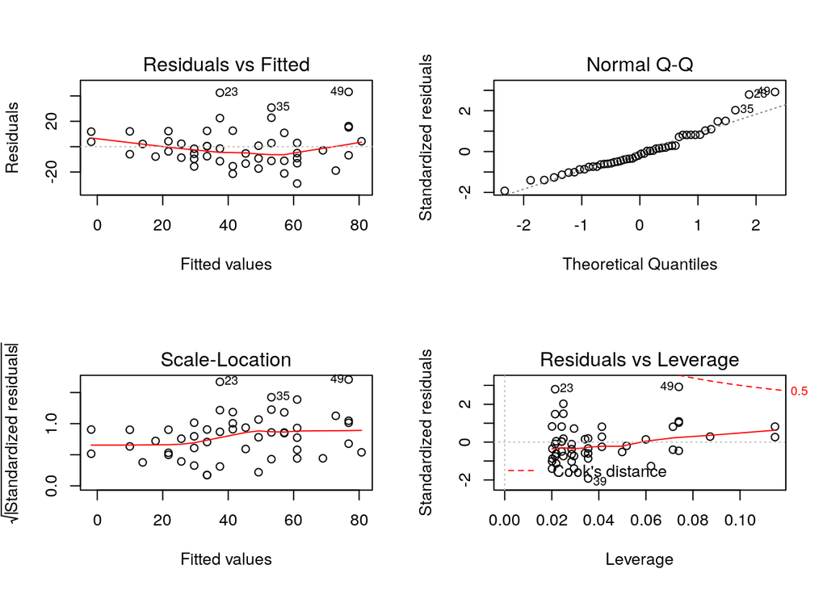

```r
par(mfrow=c(2,2)) #splitting plotting area into 2 rows and columns
plot(Model.lm) #diagnostic plots
```

> Linearity >> Residual vs Fitted plot: The red line should be fairly straight. If variance was not constant then the points would have been crowded with no patterns.

> Homoscedasticity >> Residual vs Fitted plot: If it does not exist, the plot will exhibit a funnelshape-like pattern. The variability in X variable is positive, the X values are not the same (nearly the same).

**How to check assumptions using gvlma()**

## Global Validation of Linear Models Assumptions using gvlma()

```r
gvlma::gvlma(Model.lm)
```

```
##
## Call:
## lm(formula = dist ~ speed, data = cars)
##
## Coefficients:
## (Intercept)        speed
##     -17.579        3.932
##
##
## ASSESSMENT OF THE LINEAR MODEL ASSUMPTIONS
## USING THE GLOBAL TEST ON 4 DEGREES-OF-FREEDOM:
## Level of Significance =  0.05
##
## Call:
##  gvlma::gvlma(x = Model.lm)
##
##                     Value  p-value                   Decision
## Global Stat        15.801 0.003298 Assumptions NOT satisfied!
## Skewness            6.528 0.010621 Assumptions NOT satisfied!
## Kurtosis            1.661 0.197449    Assumptions acceptable.
## Link Function       2.329 0.126998    Assumptions acceptable.
## Heteroscedasticity  5.283 0.021530 Assumptions NOT satisfied!
```

**outliers** exist, let’s remove them c(23,39,49) and check again

```r
Mod.lm<-lm(dist ~ speed, data = cars[-c(23,39,49),])
gvlma::gvlma(Mod.lm)
```

```
##
## Call:
## lm(formula = dist ~ speed, data = cars[-c(23, 39, 49), ])
##
## Coefficients:
## (Intercept)        speed
##     -16.488        3.781
##
##
## ASSESSMENT OF THE LINEAR MODEL ASSUMPTIONS
## USING THE GLOBAL TEST ON 4 DEGREES-OF-FREEDOM:
## Level of Significance =  0.05
##
## Call:
##  gvlma::gvlma(x = Mod.lm)
##
##                     Value p-value                Decision
## Global Stat        7.6969 0.10333 Assumptions acceptable.
## Skewness           2.7275 0.09863 Assumptions acceptable.
## Kurtosis           0.0304 0.86160 Assumptions acceptable.
## Link Function      2.2334 0.13506 Assumptions acceptable.
## Heteroscedasticity 2.7056 0.10000 Assumptions acceptable.
```

## Multivariate regression

> Multiple regression suffers from multicollinearity, autocorrelation, heteroskedasticity. Example data set - Boston housing data

Boston housing data **Description**

```
1. CRIM      per capita crime rate by town
2. ZN        proportion of residential land zoned for lots over
             25,000 sq.ft.
3. INDUS     proportion of non-retail business acres per town
4. CHAS      Charles River dummy variable (= 1 if tract bounds
             river; 0 otherwise)
5. NOX       nitric oxides concentration (parts per 10 million)
6. RM        average number of rooms per dwelling
7. AGE       proportion of owner-occupied units built prior to 1940
8. DIS       weighted distances to five Boston employment centres
9. RAD       index of accessibility to radial highways
10. TAX      full-value property-tax rate per $10,000
11. PTRATIO  pupil-teacher ratio by town
12. B        1000(Bk - 0.63)^2 where Bk is the proportion of blacks
             by town
13. LSTAT    % lower status of the population
14. MEDV     Median value of owner-occupied homes in $1000's
```

What is our **response variable?**

```r
house.data<-read.table('housing.data.txt', header = FALSE) # read data
colnames(house.data)<-c('CRIM', 'ZN', 'INDUS', 'CHAS', 'NOX', 'RM', 'AGE', 'DIS','RAD','TAX', 'PTRATIO', 'B', 'LSTAT','MEDV') #specify column names
head(house.data) #first five rows
```

```
##      CRIM ZN INDUS CHAS   NOX    RM  AGE    DIS RAD TAX PTRATIO      B
## 1 0.00632 18  2.31    0 0.538 6.575 65.2 4.0900   1 296    15.3 396.90
## 2 0.02731  0  7.07    0 0.469 6.421 78.9 4.9671   2 242    17.8 396.90
## 3 0.02729  0  7.07    0 0.469 7.185 61.1 4.9671   2 242    17.8 392.83
## 4 0.03237  0  2.18    0 0.458 6.998 45.8 6.0622   3 222    18.7 394.63
## 5 0.06905  0  2.18    0 0.458 7.147 54.2 6.0622   3 222    18.7 396.90
## 6 0.02985  0  2.18    0 0.458 6.430 58.7 6.0622   3 222    18.7 394.12
##   LSTAT MEDV
## 1  4.98 24.0
## 2  9.14 21.6
## 3  4.03 34.7
## 4  2.94 33.4
## 5  5.33 36.2
## 6  5.21 28.7
```

```r
dim(house.data)  #shape of data
```

```
## [1] 506  14
```

```r
is.null(house.data) #check for missing values
```

```
## [1] FALSE
```

> How can we identify the most important/significant variables to build our model?

```r
all.X.variables.model<-lm(MEDV~., data = house.data) #builds a model of the response variable and all the explanatory variables
all.X.variables.model #it is too crowded, create a subset
```

```
##
## Call:
## lm(formula = MEDV ~ ., data = house.data)
##
## Coefficients:
## (Intercept)         CRIM           ZN        INDUS         CHAS
##   3.646e+01   -1.080e-01    4.642e-02    2.056e-02    2.687e+00
##         NOX           RM          AGE          DIS          RAD
##  -1.777e+01    3.810e+00    6.922e-04   -1.476e+00    3.060e-01
##         TAX      PTRATIO            B        LSTAT
##  -1.233e-02   -9.527e-01    9.312e-03   -5.248e-01
```

```r
subVar<- subset(house.data, select = c(LSTAT, PTRATIO, TAX, INDUS, MEDV))
subVar.Model<- lm(MEDV~., data = subVar)#build a model with the subset
```

It is crowded, right? Imagine the output for X=50 observations, _ correlation matrix_

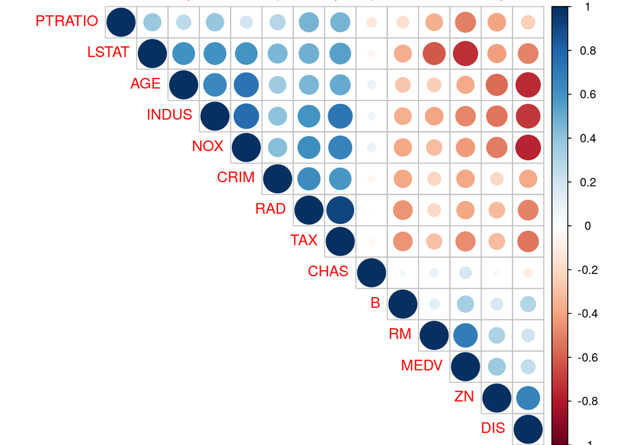

```r
cor.Matrix<-cor(house.data)
corrplot(cor.Matrix, type="upper", order="hclust", method = 'circle') #graphical display of the correlation matrix. Try changing the method='number' or 'mixed'
```

```r
sapply(house.data, cor, y=house.data$MEDV) #to calculate correlation between each other variable and the response variable MEDV
```

```
##       CRIM         ZN      INDUS       CHAS        NOX         RM
## -0.3883046  0.3604453 -0.4837252  0.1752602 -0.4273208  0.6953599
##        AGE        DIS        RAD        TAX    PTRATIO          B
## -0.3769546  0.2499287 -0.3816262 -0.4685359 -0.5077867  0.3334608
##      LSTAT       MEDV
## -0.7376627  1.0000000
```

## Visualization of data

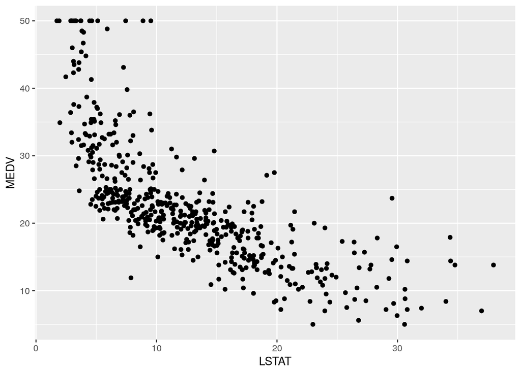

```r
ggplot(house.data, aes(LSTAT, MEDV))+ geom_point()
```

## Let’s Build the model

```r
house.model<-lm(MEDV ~ LSTAT, data = house.data)
summary(house.model)
```

```
##
## Call:
## lm(formula = MEDV ~ LSTAT, data = house.data)
##
## Residuals:
##     Min      1Q  Median      3Q     Max
## -15.168  -3.990  -1.318   2.034  24.500
##
## Coefficients:
##             Estimate Std. Error t value Pr(>|t|)
## (Intercept) 34.55384    0.56263   61.41   <2e-16 ***
## LSTAT       -0.95005    0.03873  -24.53   <2e-16 ***
## ---
## Signif. codes:  0 '***' 0.001 '**' 0.01 '*' 0.05 '.' 0.1 ' ' 1
##
## Residual standard error: 6.216 on 504 degrees of freedom
## Multiple R-squared:  0.5441, Adjusted R-squared:  0.5432
## F-statistic: 601.6 on 1 and 504 DF,  p-value: < 2.2e-16
```

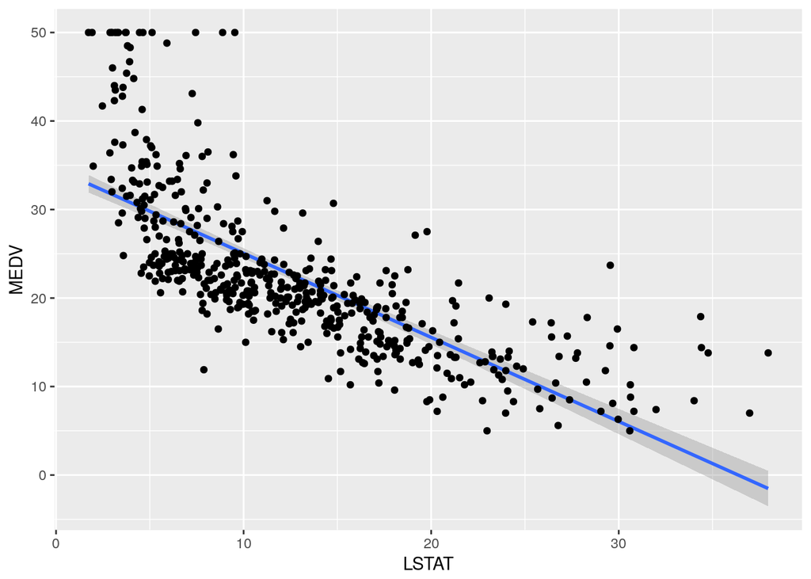

```r
ggplot(house.data, aes(LSTAT,MEDV))+geom_smooth(method = 'lm') +geom_point()
```

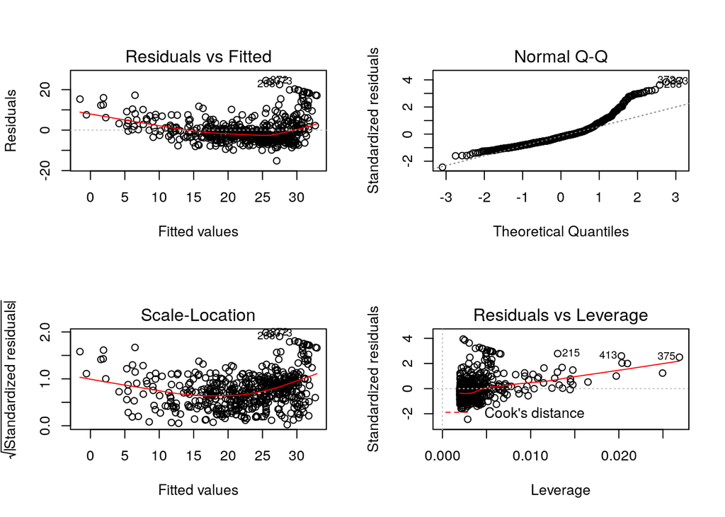

```r
par(mfrow=c(2,2))
plot(house.model) #diagnostic plots
```

> This is a non-linear example, the Residuals vs Fitted plots is curve-like and we expected it to be fairly straight to assume linearity.

> ScaleLocation also shows the nonliearity exists in the example

Model 2 with more explanatory variables

```r
house.multi.model2<-lm(MEDV ~ LSTAT+PTRATIO, data = house.data)
cor(house.data$LSTAT, house.data$PTRATIO)
```

```
## [1] 0.3740443
```

```r
summary(house.multi.model2)
```

```
##
## Call:
## lm(formula = MEDV ~ LSTAT + PTRATIO, data = house.data)
##
## Residuals:
##      Min       1Q   Median       3Q      Max
## -12.2428  -3.6398  -0.8622   1.8790  26.9036
##
## Coefficients:
##             Estimate Std. Error t value Pr(>|t|)
## (Intercept) 54.04682    2.24217  24.105   <2e-16 ***
## LSTAT       -0.82018    0.03883 -21.120   <2e-16 ***
## PTRATIO     -1.14525    0.12810  -8.941   <2e-16 ***
## ---
## Signif. codes:  0 '***' 0.001 '**' 0.01 '*' 0.05 '.' 0.1 ' ' 1
##
## Residual standard error: 5.78 on 503 degrees of freedom
## Multiple R-squared:  0.6067, Adjusted R-squared:  0.6051
## F-statistic: 387.9 on 2 and 503 DF,  p-value: < 2.2e-16
```

> Compare models

```r
anova(house.model,  house.multi.model2)
```

```
## Analysis of Variance Table
##
## Model 1: MEDV ~ LSTAT
## Model 2: MEDV ~ LSTAT + PTRATIO
##   Res.Df   RSS Df Sum of Sq      F    Pr(>F)
## 1    504 19472
## 2    503 16802  1    2670.1 79.934 < 2.2e-16 ***
## ---
## Signif. codes:  0 '***' 0.001 '**' 0.01 '*' 0.05 '.' 0.1 ' ' 1
```

> Try polynomial model on the X variables. Do not overfit.

> Predictive modelling. We build regression models to help us predict outcomes.

```r
index.no.rows<-sample(1:nrow(house.data), 0.8*nrow(house.data)) #sample row indices from data
train.Data <- house.data[index.no.rows, ]  #training data
test.Data<- house.data[-index.no.rows, ] #testing data
House.Model<- lm(MEDV ~ LSTAT+PTRATIO, data = train.Data)#build model
Predict.Model<- predict(House.Model, test.Data)#predict
Predicted.Values<- data.frame(cbind(Actual=test.Data$MEDV, Predicted=Predict.Model))#check for accuracy
head(Predicted.Values) #
```

```
##    Actual Predicted
## 6    28.7  28.42392
## 8    27.1  20.72039
## 9    16.5  11.89972
## 11   15.0  19.65667
## 18   17.5  18.25007
## 50   19.4  20.27777
```

```r
cor(Predicted.Values)#confusion matrix
```

```
##              Actual Predicted
## Actual    1.0000000 0.7889418
## Predicted 0.7889418 1.0000000
```

# Summary

> Possible solutions
> 1. For non-linearity: transform the explanatory variables such as $log(X)$, $\sqrt(Y)$, $Y^2$
> 2. For heteroscedasticity: transform the response variables such as $log(Y)$, $\sqrt(Y)$

*If the Y variable is numeric that is, continuous or discrete fit a linear regression model (regression line is linear), else if the Y variable binary fit a logistic regression model (does not require linear relationship between X and Y variables), else if the best fit line is a curve fit a ploynomial regression model*

> **All models are wrong, but some are useful – George Box**

*Most models are wrong but useful I.M.A*

# Reference materials

1. [Linear Regression](http://r-statistics.co/Linear-Regression.html)
2. [Assumptions of Linear Regression](http://r-statistics.co/Assumptions-of-Linear-Regression.html#Check%20Assumptions%20Automatically)
3. [Guide to Regression](https://www.analyticsvidhya.com/blog/2015/08/comprehensive-guide-regression/)
4. [Regression skill test Analytics Vidhya](https://www.analyticsvidhya.com/blog/2016/12/45-questions-to-test-a-data-scientist-on-regression-skill-test-regression-solution/)

## Possibles sites for data sets

5. [UCI repository](http://archive.ics.uci.edu/ml/index.php)
6. [Kaggle](http://archive.ics.uci.edu/ml/index.php)